# Overall survival in advanced lung cancer: Kaplan-Meier and Cox regression analysis

Statistical analysis plan and analysis report (NCCTG lung cancer data, R survival package)

Moussa Ndiaye

23 October 2026

# 1 Statistical analysis plan (SAP)

*This section was written before running any analysis. Commit it to the repository before the results sections so the history shows the plan came first.*

## 1.1 Objective

To describe overall survival (OS) in patients with advanced lung cancer and to estimate the association of sex, age and ECOG performance status with OS.

## 1.2 Data source

The `lung` dataset from the R `survival` package: 228 patients with advanced lung cancer from the North Central Cancer Treatment Group (NCCTG). Reference: Loprinzi CL et al. *Prospective evaluation of prognostic variables from patient-completed questionnaires.* J Clin Oncol 1994;12(3):601-607.

## 1.3 Endpoint and definitions

- **Endpoint:** overall survival, defined as time in days from enrolment to death from any cause.
- **Event:** death (`status = 2` in the source data). Patients alive at last contact are censored (`status = 1`).
- **Covariates:** sex (male, female), age at enrolment (analysed per 10-year increase), ECOG performance status (0, 1, 2 or more; the single patient with ECOG 3 is grouped with ECOG 2 to avoid an unstable category).

## 1.4 Statistical methods

1. **Descriptive statistics:** number of patients and events, median age (interquartile range), counts and percentages for categorical variables, number of missing values per variable.
2. **Follow-up:** median follow-up estimated with the reverse Kaplan-Meier method.
3. **Survival estimation:** Kaplan-Meier estimates of OS, with median OS and 95% confidence interval, overall and by sex.
4. **Group comparison:** log-rank test of OS between men and women.
5. **Cox proportional hazards regression:** univariable models for each covariate, then one multivariable model including sex, age and ECOG. Results are reported as hazard ratios (HR) with 95% confidence intervals.
6. **Assumption check:** proportional hazards assessed with scaled Schoenfeld residuals (`cox.zph`), globally and for each covariate, with residual plots.
7. **Missing data:** complete-case analysis. The number of patients excluded from each model is reported.
8. **Significance level:** two-sided alpha of 0.05. The analysis is exploratory and no adjustment for multiple testing is applied.

## 1.5 Software

# 2 Data preparation

```r
lung_df <- survival::lung %>%
  mutate(
    event  = as.integer(status == 2),                 # 1 = death, 0 = censored
    sex_f  = factor(sex, levels = c(1, 2), labels = c("Male", "Female")),
    ecog   = factor(pmin(ph.ecog, 2), levels = 0:2,
                    labels = c("0", "1", "2+")),      # ECOG 3 (n = 1) grouped with 2
    age10  = age / 10                                 # hazard ratio per 10 years
  )

stopifnot(nrow(lung_df) == 228)
```

# 3 Descriptive statistics

```r
n_total  <- nrow(lung_df)
n_events <- sum(lung_df$event)

cat("Patients:", n_total, "\n")
```

```
## Patients: 228
```

```r
cat("Deaths:", n_events, sprintf("(%.1f%%)", 100 * n_events / n_total), "\n")
```

```
## Deaths: 165 (72.4%)
```

```r
cat("Censored:", n_total - n_events, "\n\n")
```

```
## Censored: 63
```

```r
age_q <- quantile(lung_df$age, c(0.25, 0.5, 0.75))
cat(sprintf("Age, median (IQR): %.0f (%.0f - %.0f)\n", age_q[2], age_q[1], age_q[3]))
```

```
## Age, median (IQR): 63 (56 - 69)
```

```r
cat_table <- function(x, label) {
  tab <- table(x, useNA = "ifany")
  data.frame(variable = label,
             level = names(tab),
             n = as.integer(tab),
             percent = round(100 * as.integer(tab) / sum(tab), 1))
}

bind_rows(
  cat_table(lung_df$sex_f, "Sex"),
  cat_table(lung_df$ecog,  "ECOG performance status")
)
```

| variable | level | n | percent |
| --- | --- | --- | --- |
| Sex | Male | 138 | 60.5 |
| Sex | Female | 90 | 39.5 |
| ECOG performance status | 0 | 63 | 27.6 |
| ECOG performance status | 1 | 113 | 49.6 |
| ECOG performance status | 2+ | 51 | 22.4 |
| ECOG performance status | NA | 1 | 0.4 |

```r
missing_tab <- data.frame(
  variable = c("sex", "age", "ecog"),
  n_missing = c(sum(is.na(lung_df$sex_f)), sum(is.na(lung_df$age)),
                sum(is.na(lung_df$ecog)))
)
missing_tab
```

| variable | n_missing |
| --- | --- |
| sex | 0 |
| age | 0 |
| ecog | 1 |

# 4 Follow-up and survival estimation

## 4.1 Median follow-up (reverse Kaplan-Meier)

```r
fu_fit <- survfit(Surv(time, 1 - event) ~ 1, data = lung_df)
fu_tab <- summary(fu_fit)$table
cat(sprintf("Median follow-up: %.0f days (95%% CI %.0f - %.0f)\n",
            fu_tab["median"], fu_tab["0.95LCL"], fu_tab["0.95UCL"]))
```

```
## Median follow-up: 588 days (95% CI 511 - 1010)
```

## 4.2 Overall survival, all patients

```r
km_all <- survfit(Surv(time, event) ~ 1, data = lung_df)
km_tab <- summary(km_all)$table
cat(sprintf("Median OS: %.0f days (95%% CI %.0f - %.0f)\n",
            km_tab["median"], km_tab["0.95LCL"], km_tab["0.95UCL"]))
```

```
## Median OS: 310 days (95% CI 285 - 363)
```

```r
summary(km_all, times = c(180, 365, 730))
```

```
## Call: survfit(formula = Surv(time, event) ~ 1, data = lung_df)
##
##  time n.risk n.event survival std.err lower 95% CI upper 95% CI
##   180    160      63    0.722  0.0298       0.6655        0.783
##   365     65      58    0.409  0.0358       0.3447        0.486
##   730     13      38    0.116  0.0283       0.0716        0.187
```

## 4.3 Overall survival by sex

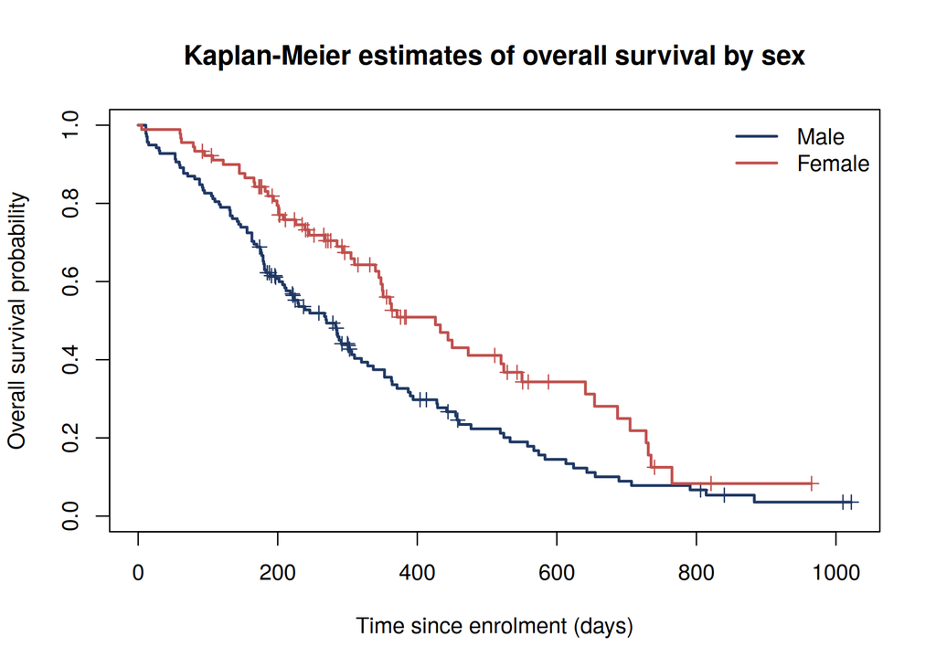

```r
km_sex <- survfit(Surv(time, event) ~ sex_f, data = lung_df)

plot(km_sex, col = c("#1F3864", "#C0504D"), lwd = 2, mark.time = TRUE,
     xlab = "Time since enrolment (days)",
     ylab = "Overall survival probability",
     main = "Kaplan-Meier estimates of overall survival by sex")
legend("topright", legend = c("Male", "Female"),
       col = c("#1F3864", "#C0504D"), lwd = 2, bty = "n")
```

```r
sex_tab <- summary(km_sex)$table
data.frame(
  sex = c("Male", "Female"),
  patients = sex_tab[, "records"],
  deaths = sex_tab[, "events"],
  median_OS_days = sex_tab[, "median"],
  CI95_lower = sex_tab[, "0.95LCL"],
  CI95_upper = sex_tab[, "0.95UCL"],
  row.names = NULL
)
```

| sex | patients | deaths | median_OS_days | CI95_lower | CI95_upper |
| --- | --- | --- | --- | --- | --- |
| Male | 138 | 112 | 270 | 212 | 310 |
| Female | 90 | 53 | 426 | 348 | 550 |

## 4.4 Log-rank test, men versus women

```r
lr <- survdiff(Surv(time, event) ~ sex_f, data = lung_df)
lr
```

```
## Call:
## survdiff(formula = Surv(time, event) ~ sex_f, data = lung_df)
##
##                N Observed Expected (O-E)^2/E (O-E)^2/V
## sex_f=Male   138      112     91.6      4.55      10.3
## sex_f=Female  90       53     73.4      5.68      10.3
##
##  Chisq= 10.3  on 1 degrees of freedom, p= 0.001
```

```r
cat(sprintf("Log-rank chi-square = %.2f, df = 1, p = %.4f\n",
            lr$chisq, pchisq(lr$chisq, df = 1, lower.tail = FALSE)))
```

```
## Log-rank chi-square = 10.33, df = 1, p = 0.0013
```

# 5 Cox proportional hazards regression

## 5.1 Univariable models

```r
fit_uni <- function(formula_rhs) {
  f <- as.formula(paste("Surv(time, event) ~", formula_rhs))
  m <- coxph(f, data = lung_df)
  tidy(m, exponentiate = TRUE, conf.int = TRUE) %>%
    mutate(n_analysed = m$n, model = "Univariable")
}

uni_results <- bind_rows(
  fit_uni("sex_f"),
  fit_uni("age10"),
  fit_uni("ecog")
)

uni_results %>%
  transmute(model, term, n_analysed,
            HR = round(estimate, 2),
            CI95_lower = round(conf.low, 2),
            CI95_upper = round(conf.high, 2),
            p_value = signif(p.value, 3))
```

| model | term | n_analysed | HR | CI95_lower | CI95_upper | p_value |
| --- | --- | --- | --- | --- | --- | --- |
| Univariable | sex_fFemale | 228 | 0.59 | 0.42 | 0.82 | 1.49e-03 |
| Univariable | age10 | 228 | 1.21 | 1.01 | 1.44 | 4.19e-02 |
| Univariable | ecog1 | 227 | 1.45 | 0.98 | 2.13 | 6.38e-02 |
| Univariable | ecog2+ | 227 | 2.54 | 1.64 | 3.93 | 3.11e-05 |

## 5.2 Multivariable model

```r
cox_multi <- coxph(Surv(time, event) ~ sex_f + age10 + ecog, data = lung_df)

cat("Patients in the model:", cox_multi$n,
    "| excluded for missing data:", nrow(lung_df) - cox_multi$n, "\n")
```

```
## Patients in the model: 227 | excluded for missing data: 1
```

```r
cat("Events in the model:", cox_multi$nevent, "\n\n")
```

```
## Events in the model: 164
```

```r
multi_results <- tidy(cox_multi, exponentiate = TRUE, conf.int = TRUE) %>%
  mutate(term = recode(term,
                       sex_fFemale = "Female vs Male",
                       age10       = "Age (per 10 years)",
                       ecog1       = "ECOG 1 vs 0",
                       `ecog2+`    = "ECOG 2+ vs 0"))

multi_results %>%
  transmute(term,
            HR = round(estimate, 2),
            CI95_lower = round(conf.low, 2),
            CI95_upper = round(conf.high, 2),
            p_value = signif(p.value, 3))
```

| term | HR | CI95_lower | CI95_upper | p_value |
| --- | --- | --- | --- | --- |
| Female vs Male | 0.58 | 0.41 | 0.80 | 0.001030 |
| Age (per 10 years) | 1.12 | 0.93 | 1.34 | 0.235000 |
| ECOG 1 vs 0 | 1.51 | 1.02 | 2.23 | 0.040200 |
| ECOG 2+ vs 0 | 2.50 | 1.60 | 3.90 | 0.000055 |

```r
cat(sprintf("\nConcordance (C-index): %.3f\n", summary(cox_multi)$concordance[1]))
```

```
##
## Concordance (C-index): 0.637
```

## 5.3 Forest plot

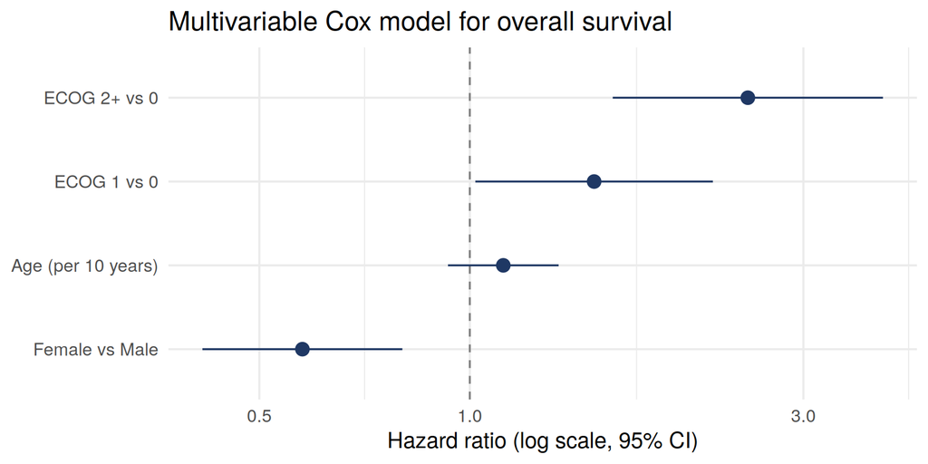

```r
ggplot(multi_results, aes(x = estimate, y = reorder(term, estimate))) +
  geom_vline(xintercept = 1, linetype = "dashed", colour = "grey50") +
  geom_pointrange(aes(xmin = conf.low, xmax = conf.high),
                  colour = "#1F3864", size = 0.6) +
  scale_x_log10() +
  labs(x = "Hazard ratio (log scale, 95% CI)", y = NULL,
       title = "Multivariable Cox model for overall survival") +
  theme_minimal(base_size = 12)
```

# 6 Proportional hazards assumption

```r
zph <- cox.zph(cox_multi, terms = FALSE)
zph
```

```
##             chisq df     p
## sex_fFemale  2.54  1 0.111
## age10        0.20  1 0.654
## ecog1        1.22  1 0.270
## ecog2+       3.04  1 0.081
## GLOBAL       5.24  4 0.264
```

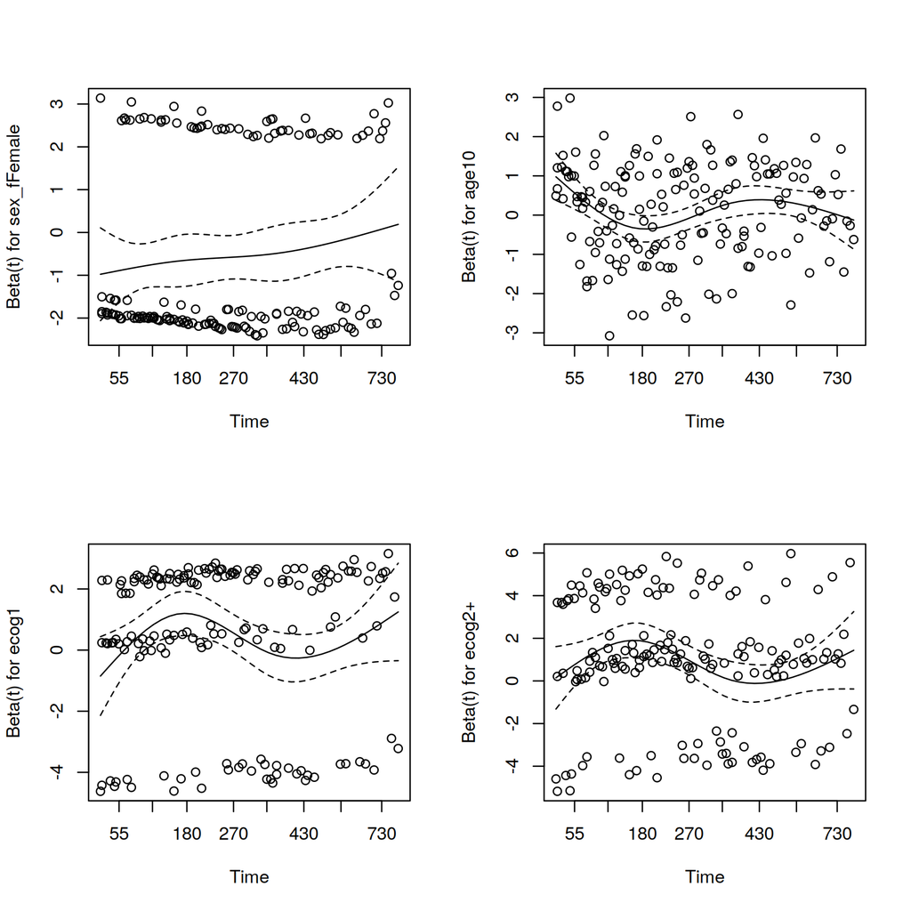

```r
par(mfrow = c(2, 2))
plot(zph)
```

```r
par(mfrow = c(1, 1))
```

*How to read this:* a small p-value for a covariate, or a clear trend in its residual plot over time, suggests that its effect changes over time. Report which covariates, if any, show such a signal, and discuss the consequence for interpreting the single hazard ratio.

# 7 Interpretation and limitations

In this cohort of 228 patients, median overall survival was 310 days (95% CI 285-363). Women survived longer than men (median 426 vs 270 days; log-rank p = 0.001). In the multivariable Cox model (227 patients, 164 deaths), female sex was associated with a lower risk of death (HR 0.58, 95% CI 0.41-0.80). A worse performance status was associated with a higher risk (ECOG 1 vs 0: HR 1.51, 95% CI 1.02-2.23; ECOG 2+ vs 0: HR 2.50, 95% CI 1.60-3.90). Age was not clearly associated with survival (HR 1.12 per 10 years, 95% CI 0.93-1.34). The proportional hazards assumption was not rejected (global test p = 0.26), although this test has limited power in a sample of this size.

Limitations: the sample is small (228 patients) and comes from a trial population from the 1980s, so results may not reflect current practice. The model describes prognosis and does not show causal effects. One patient was excluded for missing ECOG status. Several tests were run without multiplicity adjustment, so p-values are exploratory.